# PW5

Maxime BOURGEOIS

30/10/2020

1. Load the Boston dataset from MASS package. Split the dataset randomly in half.

```r
library(MASS)
library(caTools)
set.seed(18)
Boston_idx = sample(1:nrow(Boston), nrow(Boston) / 2)
# You don't know what we just did?
# open the documentation of the function sample by
# writing ?sample in the R console.
# Note that this is one of the ways to split it randomly and it is not necessary the best.
Boston_train = Boston[Boston_idx,]
Boston_test  = Boston[-Boston_idx,]
```

2. Fit a regression tree to the training data using the rpart() function from the rpart package. Name the tree Boston_tree.

```r
library(rpart)
Boston_tree <- rpart(medv ~ ., data=Boston_train)
```

3. Plot the obtained tree using the following code.

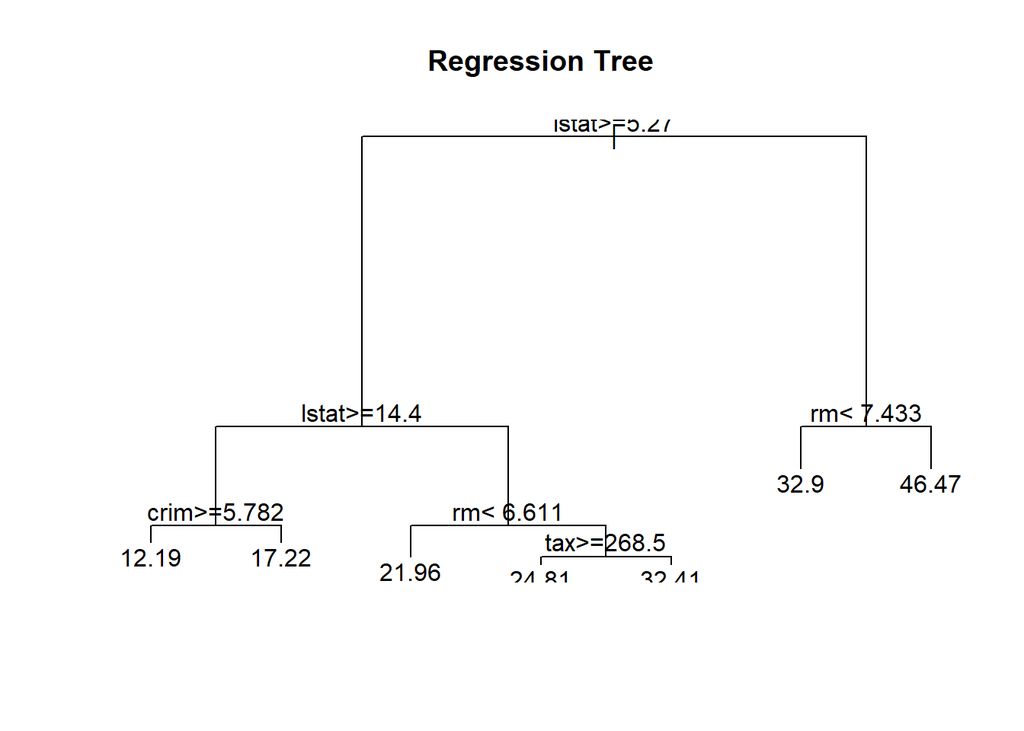

```r
plot(Boston_tree)
text(Boston_tree, pretty = 0)
title(main = "Regression Tree")
```

4. A better plot can be obtained using the rpart.plot18 package. Re-plot the tree using it. You can use the rpart.plot() function which by default, when the output is continuous, each node shows: the predicted value, and the percentage of observations in the node. You can also use the prp() function.

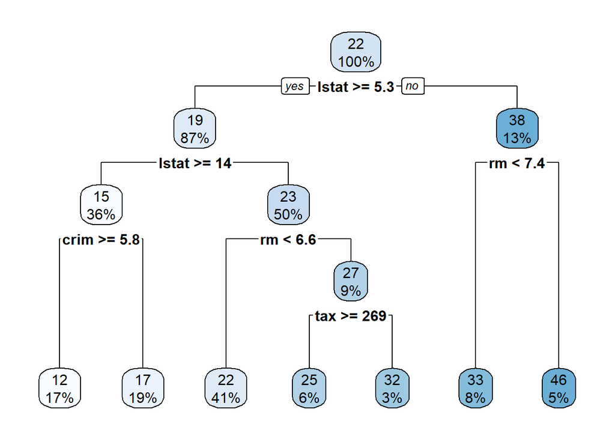

```r
#install.packages("rpart.plot")

library(rpart.plot)
rpart.plot(Boston_tree)
```

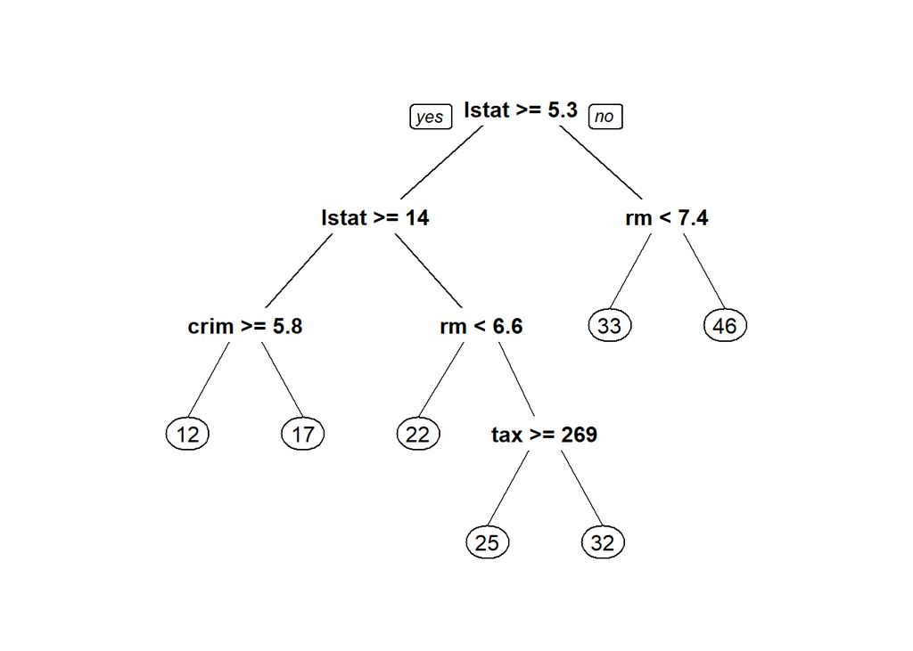

```r
prp(Boston_tree)
```

5. Print the obtained tree and print its summary. Between the things that you can see in the summary, the CP (complexity parameter) table and the importance of each variable in the model. Print the CP table using the printcp() function to see the cross validation results. Plot a comparison figure using the plotcp() function.

```r
summary(Boston_tree)
```

```
## Call:
## rpart(formula = medv ~ ., data = Boston_train)
##   n= 253
##
##           CP nsplit rel error    xerror       xstd
## 1 0.51227092      0 1.0000000 1.0079237 0.12063261
## 2 0.17530106      1 0.4877291 0.6269968 0.08009188
## 3 0.07439632      2 0.3124280 0.4181044 0.06301976
## 4 0.02929834      3 0.2380317 0.3886623 0.06765051
## 5 0.02529297      4 0.2087334 0.3489906 0.06171012
## 6 0.01419376      5 0.1834404 0.3172825 0.05624605
## 7 0.01000000      6 0.1692466 0.3051705 0.05617950
##
## Variable importance
## lstat    rm   age   tax   dis indus   nox  crim   rad    zn black
##    40    17     9     7     7     6     5     5     2     1     1
##
## Node number 1: 253 observations,    complexity param=0.5122709
##   mean=21.99802, MSE=78.49055
##   left son=2 (219 obs) right son=3 (34 obs)
##   Primary splits:
##       lstat   < 5.27    to the right, improve=0.5122709, (0 missing)
##       rm      < 6.978   to the left,  improve=0.4501026, (0 missing)
##       indus   < 7.625   to the right, improve=0.3122330, (0 missing)
##       ptratio < 19.65   to the right, improve=0.2830922, (0 missing)
##       nox     < 0.5125  to the right, improve=0.2710296, (0 missing)
##   Surrogate splits:
##       rm    < 6.978   to the left,  agree=0.917, adj=0.382, (0 split)
##       age   < 17.1    to the right, agree=0.881, adj=0.118, (0 split)
##       crim  < 0.03402 to the right, agree=0.877, adj=0.088, (0 split)
##       zn    < 87.5    to the left,  agree=0.870, adj=0.029, (0 split)
##       indus < 1.605   to the right, agree=0.870, adj=0.029, (0 split)
##
## Node number 2: 219 observations,    complexity param=0.1753011
##   mean=19.49954, MSE=33.88288
##   left son=4 (92 obs) right son=5 (127 obs)
##   Primary splits:
##       lstat   < 14.4    to the right, improve=0.4691352, (0 missing)
##       crim    < 5.84803 to the right, improve=0.3530712, (0 missing)
##       ptratio < 19.9    to the right, improve=0.3072113, (0 missing)
```

[output cut: 74 more lines]

```
##       tax     < 268.5   to the right, improve=0.4354419, (0 missing)
##       ptratio < 18.7    to the right, improve=0.3278305, (0 missing)
##       indus   < 4.415   to the right, improve=0.2124938, (0 missing)
##       rm      < 6.978   to the left,  improve=0.1449609, (0 missing)
##       nox     < 0.5225  to the right, improve=0.1122918, (0 missing)
##   Surrogate splits:
##       indus   < 2.21    to the right, agree=0.783, adj=0.286, (0 split)
##       rm      < 7.1455  to the left,  agree=0.783, adj=0.286, (0 split)
##       ptratio < 13.9    to the right, agree=0.783, adj=0.286, (0 split)
##
## Node number 22: 16 observations
##   mean=24.80625, MSE=16.75934
##
## Node number 23: 7 observations
##   mean=32.41429, MSE=13.89837
```

```r
printcp(Boston_tree)
```

```
##
## Regression tree:
## rpart(formula = medv ~ ., data = Boston_train)
##
## Variables actually used in tree construction:
## [1] crim  lstat rm    tax
##
## Root node error: 19858/253 = 78.491
##
## n= 253
##
##         CP nsplit rel error  xerror     xstd
## 1 0.512271      0   1.00000 1.00792 0.120633
## 2 0.175301      1   0.48773 0.62700 0.080092
## 3 0.074396      2   0.31243 0.41810 0.063020
## 4 0.029298      3   0.23803 0.38866 0.067651
## 5 0.025293      4   0.20873 0.34899 0.061710
## 6 0.014194      5   0.18344 0.31728 0.056246
## 7 0.010000      6   0.16925 0.30517 0.056180
```

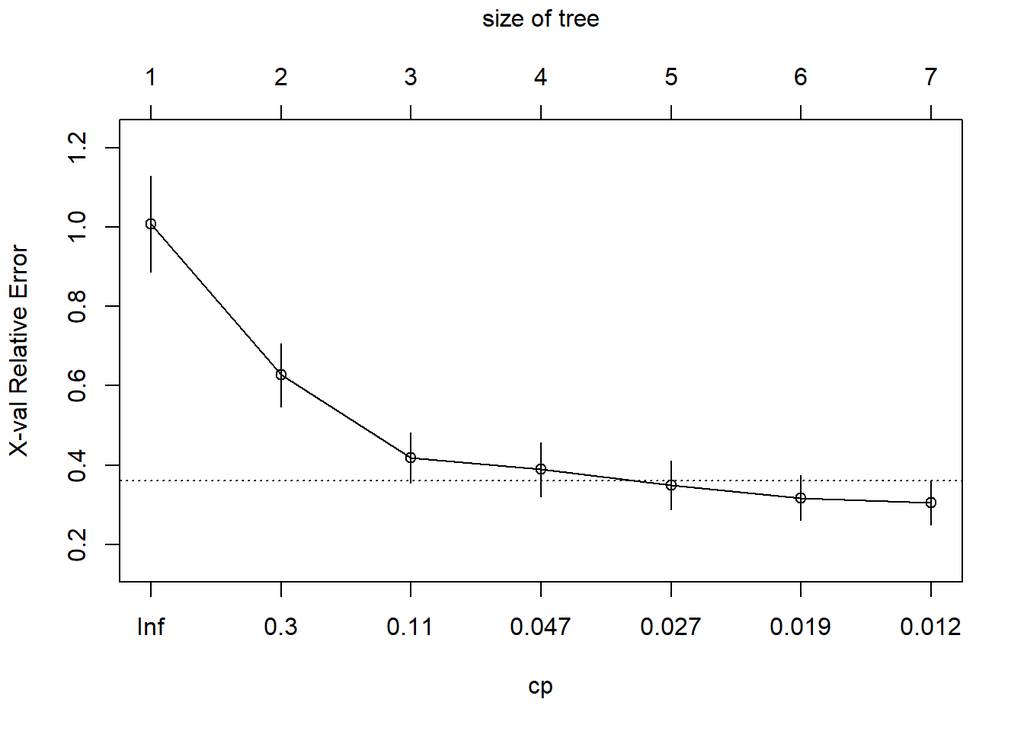

```r
plotcp(Boston_tree)
```

6. Write a function that returns the RMSE of two vectors.

```r
rmse.funct <- function(vec1, vec2)
{
  error <- vec1 - vec2
  error_squarred <- error^2
  MSE <- mean(error_squarred)
  RMSE <- MSE^(1/2)
  return (RMSE)
}
```

7. Use the function predict() to predict the response on the test set. Then calculate the RMSE obtained with tree model.

```r
pred <- predict(Boston_tree, Boston_test)

rmse.funct(Boston_test$medv, pred)
```

```
## [1] 5.051138
```

8. Fit a linear regression model on the training set. Then predict the response on the test set using the linear model. Calculate the RMSE and compare the performance of the tree and the linear regression model.

```r
linear.model <- lm(medv ~ ., Boston_train)
pred_linear.model <- predict(linear.model, Boston_test)
rmse.funct(Boston_test$medv, pred_linear.model)
```

```
## [1] 5.016083
```

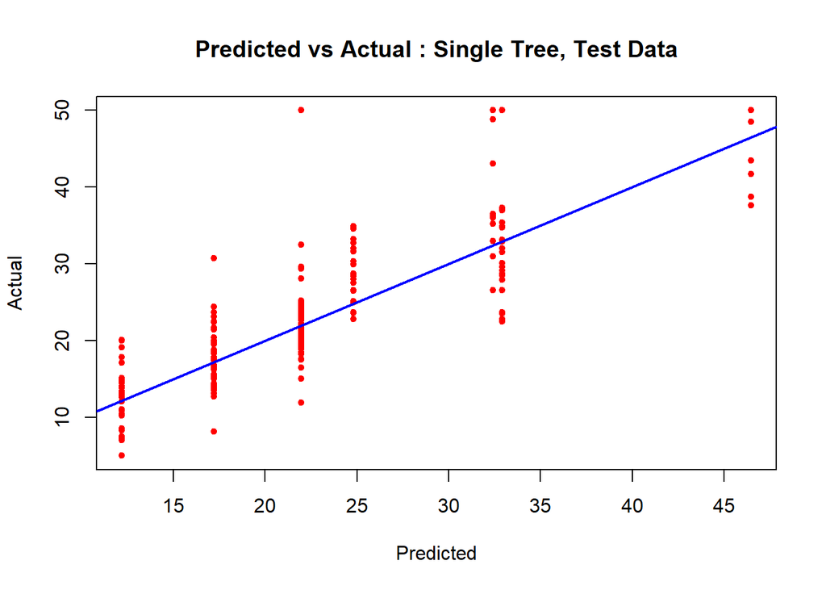

```r
plot(pred, Boston_test$medv,
     main = "Predicted vs Actual : Single Tree, Test Data",
     xlab = 'Predicted',
     ylab = 'Actual',
     col = 'red',
     pch = 20)
abline(a = 0, b = 1,
       col = 'blue',
       lwd = 2)
```

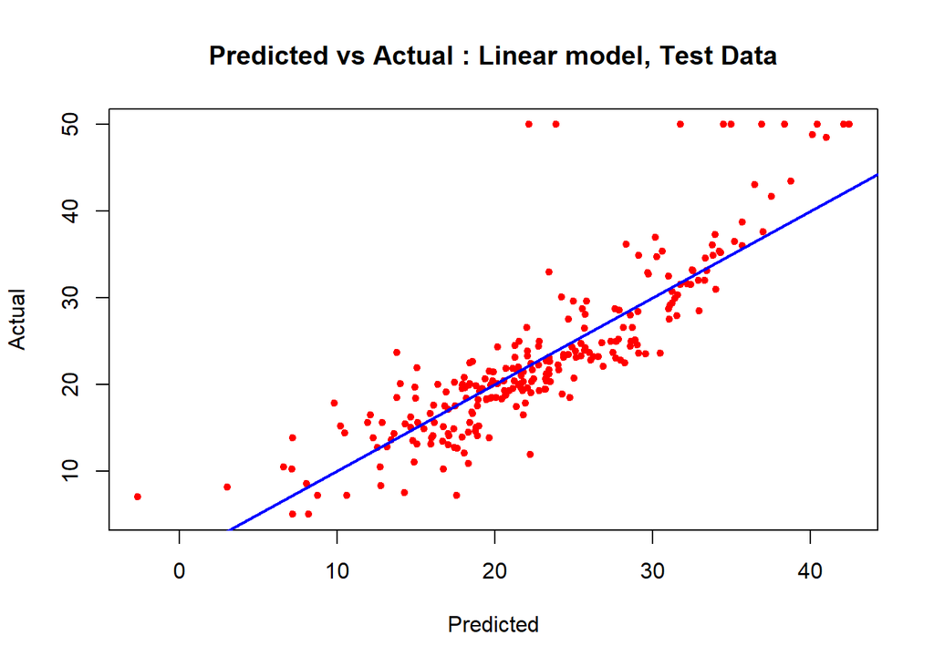

```r
plot(pred_linear.model, Boston_test$medv,
     main = "Predicted vs Actual : Linear model, Test Data",
     xlab = 'Predicted',
     ylab = 'Actual',
     col = 'red',
     pch = 20)
abline(a = 0, b = 1,
       col = 'blue',
       lwd = 2)
```

```r
#install.packages('Rtools')
#install.packages('randomForest')

library(randomForest)
rf_bagged <- randomForest(medv ~ ., data = Boston_train)
rf_bagged
```

```
##
## Call:
##  randomForest(formula = medv ~ ., data = Boston_train)
##                Type of random forest: regression
##                      Number of trees: 500
## No. of variables tried at each split: 4
##
##           Mean of squared residuals: 12.3674
##                     % Var explained: 84.24
```

10. Predict the response on the test set using the bagging model. Calculate the RMSE. Is the performance of the model better than linear regression or a simple tree?

```r
pred_rf_bagged <- predict(rf_bagged, Boston_test)
rmse.funct(Boston_train$medv, pred_rf_bagged)
```

```
## [1] 11.5388
```

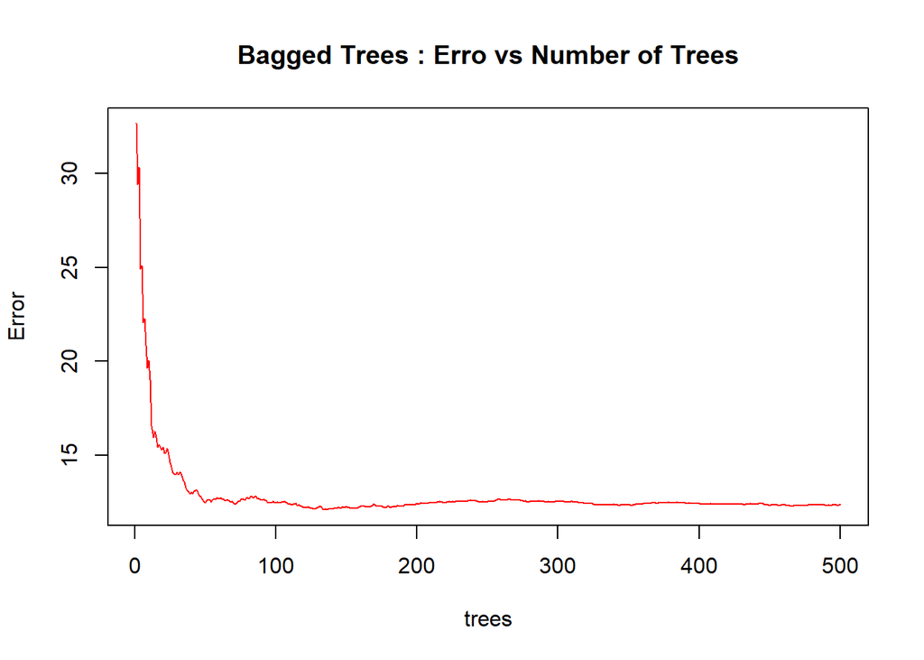

```r
plot(rf_bagged,
     col = 'red',
     main = "Bagged Trees : Erro vs Number of Trees")
```

11. Fit a random forest on the training set and compare its performance with the previous models by calculating the predictions and the RMSE

```r
rf <- randomForest(medv ~ ., data = Boston_train, mtry = length(Boston_train)/3)

pred_rf <- predict(rf, Boston_test)
rmse.funct(Boston_train$medv, pred_rf)
```

```
## [1] 11.68453
```

12. Use the function importance() from the randomForest package to see the most important predictors in the obtained random forest model. What are the three most important predictors? Did you find the same results when you selected the best predictors for the linear regression model during session 2?

```r
importance(rf)
```

```
##         IncNodePurity
## crim       1355.66993
## zn           97.82889
## indus      1057.51755
## chas         51.25449
## nox        1030.07861
## rm         4896.11160
## age         423.86193
## dis         819.03311
## rad         152.12050
## tax         608.99936
## ptratio     938.33028
## black       369.96116
## lstat      7476.74016
```

13. Plot the importance of the predictors to the model using the varImpPlot() function.

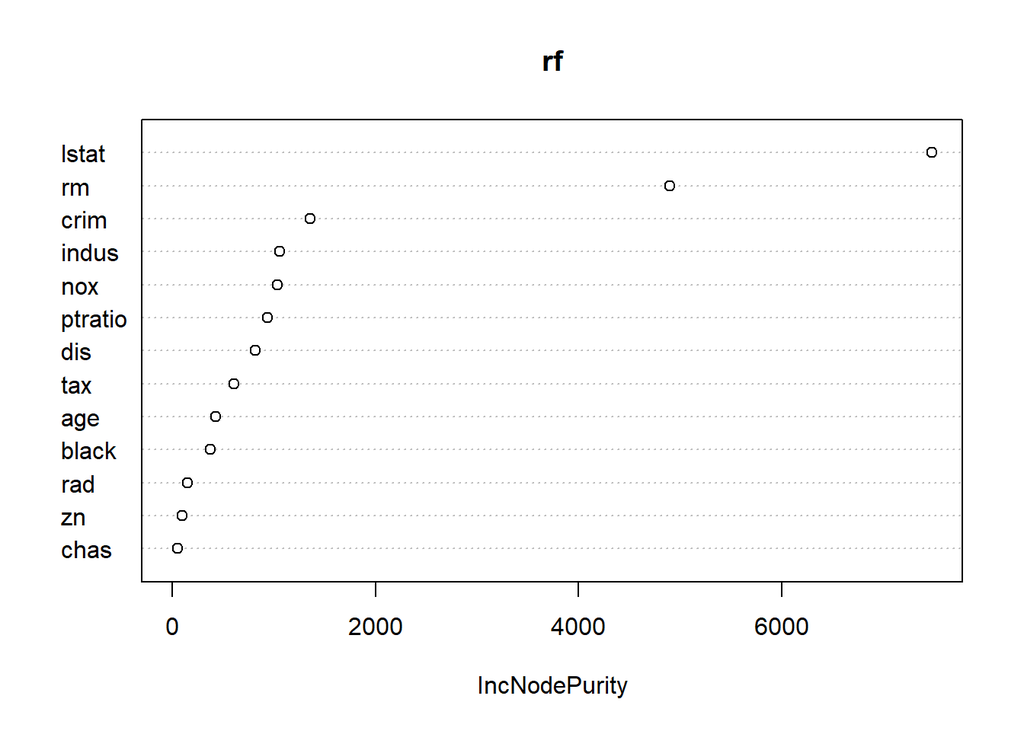

```r
varImpPlot(rf)
```

14. Using the gbm() function like following, fit a boosted model on the training set. Then compare its performance with the previous models by calculating the predictions and the RMSE.

```r
#install.packages("Rtools")
#install.packages("gbm")

library(gbm)
Boston_boost = gbm(medv ~ ., data = Boston_train, distribution = "gaussian", n.trees = 5000, interaction.depth = 4, shrinkage = 0.01)

boost_pred = predict(Boston_boost, newdata = Boston_test )
```

```
## Using 5000 trees...
```

```r
boost_error = rmse.funct(boost_pred, Boston_test[,14])

boost_error
```

```
## [1] 3.668534
```

15. Show the summary of the boosted model. A figure of the variable importance will be shown.

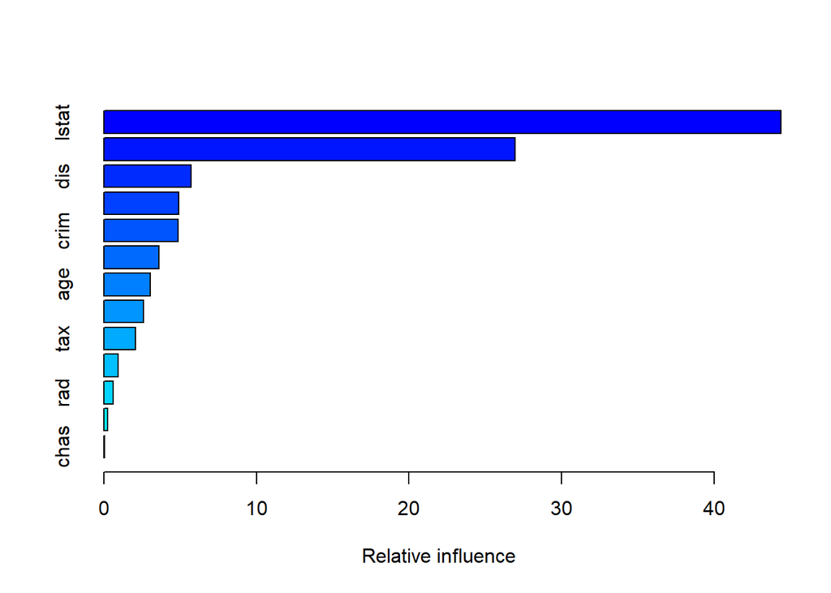

```
##             var     rel.inf
## lstat     lstat 44.38409659
## rm           rm 26.96937608
## dis         dis  5.70384719
## nox         nox  4.88895755
## crim       crim  4.88403752
## black     black  3.59328640
## age         age  3.05374376
## ptratio ptratio  2.59493143
## tax         tax  2.06093484
## indus     indus  0.94612804
## rad         rad  0.61683765
## zn           zn  0.25401232
## chas       chas  0.04981063
```

```r
summary(Boston_boost)
```

16. Reproduce the following comparison: A table in which we show the obtained RMSE with each tested model, you can create a 5×2 data.frame in which you put the names of the models and the corresponding RMSE. To visualize the data frame in the compiled html report you can use the kable() function from the knitr package. Or, compare the models by plotting the Actual (reality) response values against the predicted values.

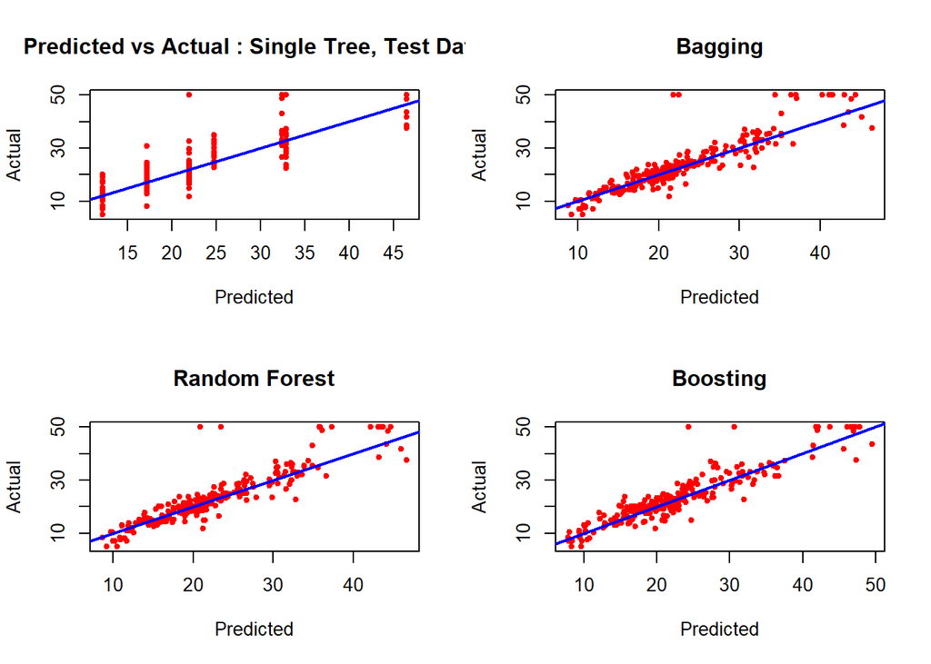

```r
par(mfrow = c(2,2))

plot(pred, Boston_test$medv,
     main = "Predicted vs Actual : Single Tree, Test Data",
     xlab = "Predicted",
     ylab = "Actual",
     col = "red",
     pch = 20)
abline(a = 0, b = 1,
       col = 'blue',
       lwd = 2)

plot(pred_rf_bagged, Boston_test[,14],
     main = "Bagging",
     xlab = "Predicted",
     ylab = "Actual",
     col = "red",
     pch = 20)
abline(a = 0, b =1,
       col = "blue",
       lwd = 2)

plot(pred_rf,Boston_test[,14],
     main = "Random Forest",
     xlab = "Predicted",
     ylab = "Actual",
     col = "red",
     pch = 20)
abline(a = 0, b =1,
       col = "blue",
       lwd = 2)

plot(boost_pred,Boston_test[,14],
     main = "Boosting",
     xlab = "Predicted",
     ylab = "Actual",
     col = "red",
     pch = 20)
abline(a = 0, b =1,
       col = "blue",
       lwd = 2)
```

Classification tree :

```r
spam <- read.csv("spam.csv")
head(spam)
```

```
##   spam make address  all X3d  our over remove internet order mail receive will
## 1 TRUE 0.00    0.64 0.64   0 0.32 0.00   0.00     0.00  0.00 0.00    0.00 0.64
## 2 TRUE 0.21    0.28 0.50   0 0.14 0.28   0.21     0.07  0.00 0.94    0.21 0.79
## 3 TRUE 0.06    0.00 0.71   0 1.23 0.19   0.19     0.12  0.64 0.25    0.38 0.45
## 4 TRUE 0.00    0.00 0.00   0 0.63 0.00   0.31     0.63  0.31 0.63    0.31 0.31
## 5 TRUE 0.00    0.00 0.00   0 0.63 0.00   0.31     0.63  0.31 0.63    0.31 0.31
## 6 TRUE 0.00    0.00 0.00   0 1.85 0.00   0.00     1.85  0.00 0.00    0.00 0.00
##   people report addresses free business email  you credit your font X000 money
## 1   0.00   0.00      0.00 0.32     0.00  1.29 1.93   0.00 0.96    0 0.00  0.00
## 2   0.65   0.21      0.14 0.14     0.07  0.28 3.47   0.00 1.59    0 0.43  0.43
## 3   0.12   0.00      1.75 0.06     0.06  1.03 1.36   0.32 0.51    0 1.16  0.06
## 4   0.31   0.00      0.00 0.31     0.00  0.00 3.18   0.00 0.31    0 0.00  0.00
## 5   0.31   0.00      0.00 0.31     0.00  0.00 3.18   0.00 0.31    0 0.00  0.00
## 6   0.00   0.00      0.00 0.00     0.00  0.00 0.00   0.00 0.00    0 0.00  0.00
##   hp hpl george X650 lab labs telnet X857 data X415 X85 technology X1999 parts
```

[output cut: 20 more lines]

```r
str(spam)
```

```
## 'data.frame':    4601 obs. of  58 variables:
##  $ spam      : logi  TRUE TRUE TRUE TRUE TRUE TRUE ...
##  $ make      : num  0 0.21 0.06 0 0 0 0 0 0.15 0.06 ...
##  $ address   : num  0.64 0.28 0 0 0 0 0 0 0 0.12 ...
##  $ all       : num  0.64 0.5 0.71 0 0 0 0 0 0.46 0.77 ...
##  $ X3d       : num  0 0 0 0 0 0 0 0 0 0 ...
##  $ our       : num  0.32 0.14 1.23 0.63 0.63 1.85 1.92 1.88 0.61 0.19 ...
##  $ over      : num  0 0.28 0.19 0 0 0 0 0 0 0.32 ...
##  $ remove    : num  0 0.21 0.19 0.31 0.31 0 0 0 0.3 0.38 ...
##  $ internet  : num  0 0.07 0.12 0.63 0.63 1.85 0 1.88 0 0 ...
##  $ order     : num  0 0 0.64 0.31 0.31 0 0 0 0.92 0.06 ...
##  $ mail      : num  0 0.94 0.25 0.63 0.63 0 0.64 0 0.76 0 ...
##  $ receive   : num  0 0.21 0.38 0.31 0.31 0 0.96 0 0.76 0 ...
##  $ will      : num  0.64 0.79 0.45 0.31 0.31 0 1.28 0 0.92 0.64 ...
##  $ people    : num  0 0.65 0.12 0.31 0.31 0 0 0 0 0.25 ...
```

[output cut: 44 more lines]

Split dataset into trainimg & test sets :

```r
set.seed(1000)
spam_idx = sample(1:nrow(spam), nrow(spam) / 2)

spam.train = spam[spam_idx,]
spam.test  = spam[-spam_idx,]
```

```r
library(rpart)
spam.tree <- rpart(spam ~ ., data=spam.train)
```

Plot the obtained tree :

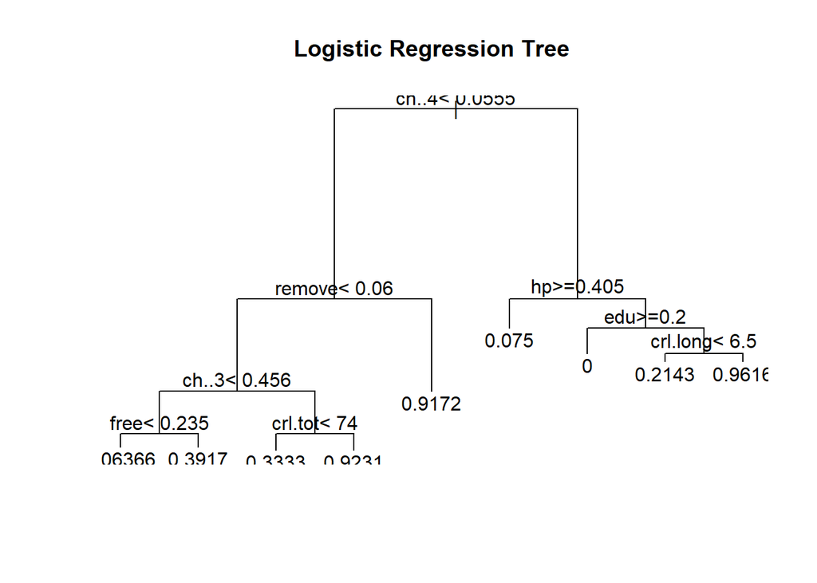

```r
plot(spam.tree)
text(spam.tree, pretty = 0)
title(main = "Logistic Regression Tree")
```

Random forest :

```r
library(randomForest)
spam.rm.tree <- randomForest(spam ~ ., data=spam.train)
```

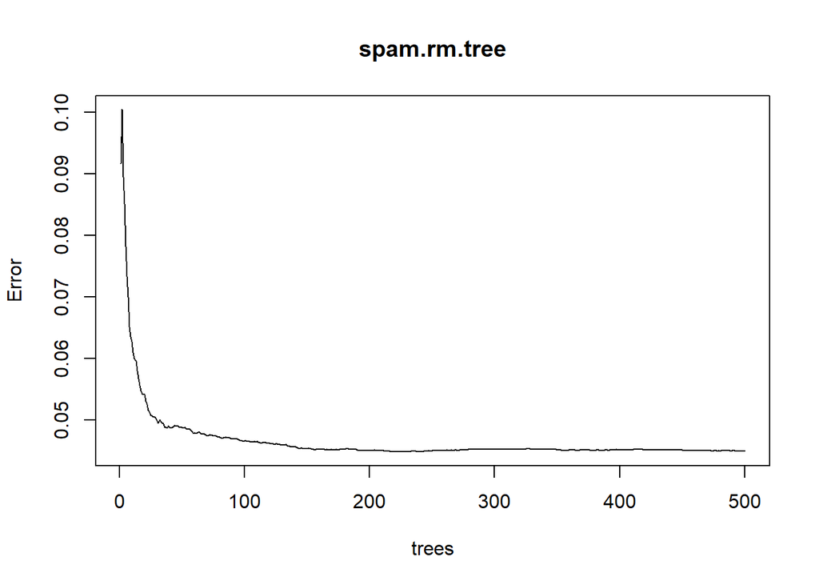

```r
plot(spam.rm.tree)
```

```r
# title(main = "Logistic Regression Random Forest")
```

Boosting :

```r
library(gbm)
spam.boost = gbm(spam ~ ., data = spam.train)
```

```
## Distribution not specified, assuming bernoulli ...
```

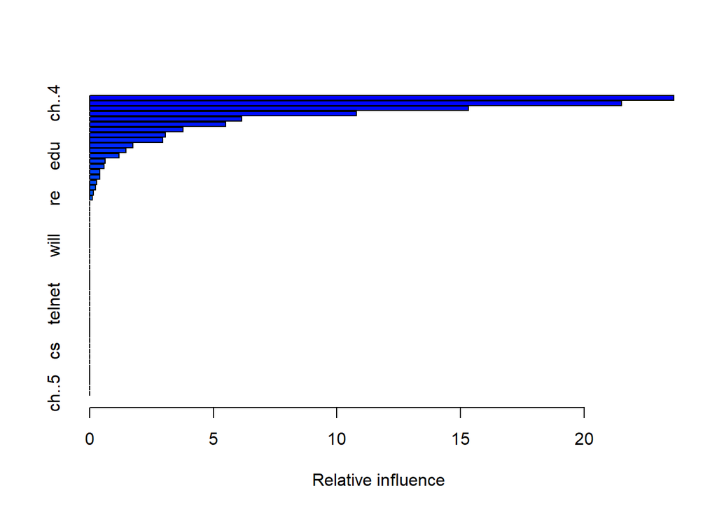

```
##                   var    rel.inf
## ch..3           ch..3 23.6306968
## ch..4           ch..4 21.5273198
## remove         remove 15.3223973
## free             free 10.7982556
## crl.ave       crl.ave  6.1437044
## hp                 hp  5.5057956
## your             your  3.7852057
## crl.long     crl.long  3.0644423
## our               our  2.9571501
## george         george  1.7438463
## money           money  1.4787865
## edu               edu  1.1815046
## business     business  0.6307244
## X1999           X1999  0.5884216
## meeting       meeting  0.4189935
## internet     internet  0.4186151
## font             font  0.2910845
## crl.tot       crl.tot  0.2310939
## X000             X000  0.1612465
## re                 re  0.1207155
## make             make  0.0000000
## address       address  0.0000000
## all               all  0.0000000
## X3d               X3d  0.0000000
## over             over  0.0000000
## order           order  0.0000000
## mail             mail  0.0000000
## receive       receive  0.0000000
## will             will  0.0000000
## people         people  0.0000000
## report         report  0.0000000
## addresses   addresses  0.0000000
## email           email  0.0000000
## you               you  0.0000000
## credit         credit  0.0000000
## hpl               hpl  0.0000000
## X650             X650  0.0000000
## lab               lab  0.0000000
## labs             labs  0.0000000
## telnet         telnet  0.0000000
## X857             X857  0.0000000
## data             data  0.0000000
## X415             X415  0.0000000
## X85               X85  0.0000000
## technology technology  0.0000000
## parts           parts  0.0000000
## pm                 pm  0.0000000
## direct         direct  0.0000000
## cs                 cs  0.0000000
## original     original  0.0000000
## project       project  0.0000000
## table           table  0.0000000
## conference conference  0.0000000
## ch.               ch.  0.0000000
## ch..1           ch..1  0.0000000
## ch..2           ch..2  0.0000000
## ch..5           ch..5  0.0000000
```

```r
summary(spam.boost)
```